# APC Analysis

shelloren

Last updated: March 29, 2019

# 1 Background

## 1.1 Disclaimer

The following coursebook is produced by the team at [Algoritma](https://algorit.ma) for its Data Science Academy internal training. The coursebook is intended for a restricted audience only, i.e. the individuals and organizations having received this coursebook directly from the training organization. It may not be reproduced, distributed, translated or adapted in any form outside these individuals and organizations without permission.

## 1.2 Libraries and Setup

You will need install the package to do APC analysis if it’s not already downloaded onto your machine.

```r
library(broom)
library(tidyverse)
```

## 1.3 Training Objectives

The primary objective of this course is to provide a comprehensive introduction to the science of APC analysis. The syllabus covers:

- **APC Analysis**
- Workflow
- APC in R

# 2 APC Analysis

Age-period-cohort (APC) analysis is widely used for capturing the characteristics in time-varying elements, and mostly used in epidemiology and demographic fields or we could say this is identification problem. In particular, APC analysis discerns three types of time varying phenomena[^1]:

- **Age effects**:

  Age effect is variations linked to biological and social processes of aging specific to individuals. They include physiologic changes and accumulation of social experiences linked to aging, but unrelated to the time period or birth cohort to which an individual belongs.
- **Period effects**:

  Period effect is the result from external factors that equally affect all age groups at a particular calendar time. It could arise from a range of environmental, social and economic factors e.g. war, famine, economic crisis. Methodological changes in outcome definitions, classifications, or method of data collection could also lead to period effects in data.
- **Cohort effects**:

  Cohort effect is variations resulting from the unique experience/exposure of a group of subjects (cohort) as they move across time. In epidemiology, a cohort effect is conceptualized as an interaction or effect modification due to a period effect that is differentially experienced through age-specific exposure or susceptibility to that event or cause.

  In contrast to this conceptualization of cohort effect as an effect modification in epidemiology, sociological literature consider cohort effect as a structural factor representing the sum of all unique exposures experienced by the cohort from birth. In this case, age and period effect are conceived as confounders of cohort effect and APC analysis aims to disentangle the independent effect of age, period and cohort. Most of the APC analysis strategies are based on the sociological model of cohort effect, conceptualize independent effect of age, period and cohort effect.

**Identification problem in APC:** APC analysis aims at describing and estimating the independent effect of age, period and cohort on the outcome under study. The different strategies used aims to partition variance into the unique components attributable to age, period, and cohort effects. However, there is a major impediment to independently estimating age, period, and cohort effects by modeling the data which is know as the “identification problem” in APC. This is due to the exact linear dependency among age, period, and cohort: $Period – Age = Cohort$; that is, given the calendar year and age, one can determine the cohort (birth year). The presence of perfectly collinear predictors (age, period and cohort) in a regression model will produce a singular non-identifiable design matrix, from which it is statistically impossible to estimate unique estimates for the three effects.

Age-Period-Cohort will be exist together at once, we saperate them to see which more important driving the societal changes. But those sometimes could be dificult because three of them were collinear.

## 2.1 Conventional solutions to APC

Turn APC with regression in order to estimate parameters (trends and deviations). The parameters are combined to produce functions that describe relationships between the observed number of suicides and age, calendar period, and birth cohort.

A popular approach to resolving the identification problem was by using constraint based regression analysis (Constrained Coefficients GLIM estimator (CGLIM)). In this strategy additional constrains are placed on one of the categories of at least one predictor to simultaneously estimate the age period and cohort effect. Thus assuming some categories of age groups, cohorts or time periods have identical effects on the dependent variable it becomes possible to estimate independent effect of age period and cohort[^2]

However, the results from this analysis will depend on constrains chosen by the investigator based on external information. The validity of the constraints chosen will depend on the theoretical preconception about the categories of parameter that are identical, is often subjective and there is no empirical way to confirm the validity of the chosen constraints [^3].

### 2.1.1 APC with `lm`

I’ve prepared the following data originally made available in [kaggle](https://www.kaggle.com/russellyates88/suicide-rates-overview-1985-to-2016). We’ll read the data into our workspace:

```r
# load data
suicides <- read_csv("data/suicides.csv")

# quick check
glimpse(suicides)
```

```
## Observations: 27,820
## Variables: 6
## $ suicides <dbl> 21, 16, 14, 1, 9, 1, 6, 4, 1, 0, 0, 0, 2, 17, 1, 14, 4,…
## $ age      <dbl> 20, 44, 20, 75, 30, 75, 44, 30, 64, 10, 64, 10, 75, 20,…
## $ period   <dbl> 1987, 1987, 1987, 1987, 1987, 1987, 1987, 1987, 1987, 1…
## $ cohort   <dbl> 1967, 1943, 1967, 1912, 1957, 1912, 1943, 1957, 1923, 1…
## $ sex      <chr> "male", "male", "female", "male", "male", "female", "fe…
## $ country  <chr> "Albania", "Albania", "Albania", "Albania", "Albania", …
```

- `sucides`: number of suicides
- `age`: *self explanatory*
- `period`: current year when the data is collected
- `cohort`: birth year of each age group during that `period`
- `sex`: gender indicator
- `country`: country indicator

We need to readjust APC variable to start with:

```r
# readjust apc variable
suicides <- suicides %>%
  mutate(age_squared = age ^ 2) %>%
  mutate_at(vars(period, cohort), funs(as.factor(.))) %>%
  select(suicides, age, age_squared, period, cohort, everything())

suicides
```

| suicides | age | age_squared | period | cohort | sex | country |
| --- | --- | --- | --- | --- | --- | --- |
| 21 | 20 | 400 | 1987 | 1967 | male | Albania |
| 16 | 44 | 1936 | 1987 | 1943 | male | Albania |
| 14 | 20 | 400 | 1987 | 1967 | female | Albania |
| 1 | 75 | 5625 | 1987 | 1912 | male | Albania |
| 9 | 30 | 900 | 1987 | 1957 | male | Albania |
| 1 | 75 | 5625 | 1987 | 1912 | female | Albania |
| 6 | 44 | 1936 | 1987 | 1943 | female | Albania |
| 4 | 30 | 900 | 1987 | 1957 | female | Albania |
| 1 | 64 | 4096 | 1987 | 1923 | male | Albania |
| 0 | 10 | 100 | 1987 | 1977 | female | Albania |

[output cut: 9990 more lines]

Now we have our data that contained APC variables. For the next step we applied linear regression to extract coefficient of APC with equation:

$$y_{ij} = \alpha_{ij} + \beta_{ij}Age + \beta_{ij}Age^2 + e_{ij}$$

where $i$ is representing period, and $j$ representing cohort.

```r
apc_lm <- lm(suicides ~ age + age_squared + period + cohort, suicides)

summary(apc_lm)
```

```
##
## Call:
## lm(formula = suicides ~ age + age_squared + period + cohort,
##     data = suicides)
##
## Residuals:
##     Min      1Q  Median      3Q     Max
##  -579.9  -278.9  -145.3     0.8 21762.0
##
## Coefficients: (1 not defined because of singularities)
##               Estimate Std. Error t value             Pr(>|t|)
## (Intercept) -339.22638   86.84338  -3.906             0.000094 ***
## age           30.40751    2.32352  13.087 < 0.0000000000000002 ***
## age_squared   -0.32299    0.02171 -14.878 < 0.0000000000000002 ***
## period1986   -15.26465   76.16068  -0.200               0.8411
## period1987   -38.53047   78.43160  -0.491               0.6232
## period1988    -6.43966   77.80014  -0.083               0.9340
## period1989    66.94468   73.26358   0.914               0.3609
## period1990    60.13425   74.21306   0.810               0.4178
## period1991    67.48220   71.88165   0.939               0.3478
## period1992   117.89746   75.17127   1.568               0.1168
## period1993   147.71811   76.42130   1.933               0.0533 .
## period1994   138.08179   73.26564   1.885               0.0595 .
## period1995    66.26804   58.33994   1.136               0.2560
## period1996    31.27579   65.47891   0.478               0.6329
## period1997     4.76593   74.90887   0.064               0.9493
## period1998    19.28488   73.47197   0.262               0.7930
## period1999    61.33906   63.39151   0.968               0.3332
## period2000    44.19804   69.85120   0.633               0.5269
## period2001    36.71037   69.35817   0.529               0.5966
## period2002    89.40211   72.32410   1.236               0.2164
## period2003   114.10428   73.45058   1.553               0.1203
## period2004   103.85482   71.23562   1.458               0.1449
## period2005    53.98893   57.77302   0.935               0.3501
## period2006    12.47963   70.09375   0.178               0.8587
## period2007   -11.43421   76.46974  -0.150               0.8811
## period2008     0.25884   77.20994   0.003               0.9973
## period2009     6.49784   67.83942   0.096               0.9237
## period2010    -0.99290   72.96721  -0.014               0.9891
## period2011    -1.10585   74.49438  -0.015               0.9882
```

[output cut: 91 more lines]

```
## cohort1997    88.59953  124.53294   0.711               0.4768
## cohort1998    76.83842  125.30561   0.613               0.5397
## cohort1999    71.26135  121.94267   0.584               0.5590
## cohort2000    78.44310  123.67906   0.634               0.5259
## cohort2001    79.48047  123.21747   0.645               0.5189
## cohort2002    40.79277  127.30436   0.320               0.7486
## cohort2003    18.08633  128.90684   0.140               0.8884
## cohort2004    15.46515  127.77105   0.121               0.9037
## cohort2005          NA         NA      NA                   NA
## ---
## Signif. codes:  0 '***' 0.001 '**' 0.01 '*' 0.05 '.' 0.1 ' ' 1
##
## Residual standard error: 889.6 on 27692 degrees of freedom
## Multiple R-squared:  0.03193,    Adjusted R-squared:  0.02749
## F-statistic: 7.193 on 127 and 27692 DF,  p-value: < 0.00000000000000022
```

Use package [broom](https://cran.r-project.org/web/packages/broom/vignettes/broom.html) to constructs a data frame that summarizes the model’s statistical findings.

```r
apc_tidy <- tidy(apc_lm)

apc_tidy
```

| term | estimate | std.error | statistic | p.value |
| --- | --- | --- | --- | --- |
| (Intercept) | -339.22637987 | 86.84337612 | -3.9061859987 | 0.00009398689368993416715352545720563171016692649573087692 |
| age | 30.40751349 | 2.32351704 | 13.0868476449 | 0.00000000000000000000000000000000000000511238029849859391 |
| age_squared | -0.32298956 | 0.02170981 | -14.8775875857 | 0.00000000000000000000000000000000000000000000000007183316 |
| period1986 | -15.26464969 | 76.16068137 | -0.2004269055 | 0.84114819068232438148413621092913672327995300292968750000 |
| period1987 | -38.53047035 | 78.43159556 | -0.4912621001 | 0.62324497522376876013083801808534190058708190917968750000 |
| period1988 | -6.43965995 | 77.80013959 | -0.0827718302 | 0.93403356671857484805343574407743290066719055175781250000 |
| period1989 | 66.94468137 | 73.26358245 | 0.9137511316 | 0.36085558539772155661751185107277706265449523925781250000 |
| period1990 | 60.13425245 | 74.21305923 | 0.8102920574 | 0.41777930227582127375995924012386240065097808837890625000 |
| period1991 | 67.48219583 | 71.88164545 | 0.9387959250 | 0.34784371955948412136194747290574014186859130859375000000 |
| period1992 | 117.89746239 | 75.17126837 | 1.5683846363 | 0.11680282021628383970490716592394164763391017913818359375 |

[output cut: 118 more lines]

From tidied coefficients, we need to tidy our results, starting from period and cohort first:

```r
pc_tidy <- apc_tidy %>%
  mutate(
    key = str_replace_all(term, "[:digit:]", ""),
    value = str_replace_all(term, "[:alpha:]", "") %>% as.numeric()
  ) %>% # seperate digit number and alphabet of term
  select(key, value, estimate) %>%
  filter(key == "period" | key == "cohort") %>%
  spread(key, value)
pc_tidy
```

| estimate | cohort | period |
| --- | --- | --- |
| -176.96659489 | NA | 2016 |
| -129.92048492 | 1973 | NA |
| -122.17291015 | 1974 | NA |
| -114.37740591 | 1918 | NA |
| -111.87468192 | 1919 | NA |
| -94.85713777 | 1972 | NA |
| -89.94059868 | 1983 | NA |
| -84.16652847 | 1984 | NA |
| -82.84906496 | 1917 | NA |
| -62.24102351 | 1928 | NA |

[output cut: 115 more lines]

Then we can extract and tidy each coefficient using code in the chunk below:

```r
age_coef <- apc_tidy %>%
  filter(term == "age") %>%
  pull(estimate)

age_squared_coef <- apc_tidy %>%
  filter(term == "age_squared") %>%
  pull(estimate)

period_coef <- pc_tidy %>%
  select(x = period, y = estimate) %>%
  drop_na()

cohort_coef <- pc_tidy %>%
  select(x = cohort, y = estimate) %>%
  drop_na()
```

Now we can calculate the age effect, then combine all the coefficient together:

```r
apc_all <- suicides %>%
  mutate(age_effect = (age * age_coef) + (age_squared * age_squared_coef)) %>%
  select(x = age, y = age_effect) %>%
  distinct() %>%
  mutate(group = "Age Effect") %>%
  bind_rows(mutate(period_coef, group = "Period Effect")) %>%
  bind_rows(mutate(cohort_coef, group = "Cohort Effect")) %>%
  select(group, x, y) %>%
  arrange(x)

apc_all
```

| group | x | y |
| --- | --- | --- |
| Age Effect | 10 | 271.77617844 |
| Age Effect | 20 | 478.95444405 |
| Age Effect | 30 | 621.53479684 |
| Age Effect | 44 | 712.62279721 |
| Age Effect | 64 | 623.11560841 |
| Age Effect | 75 | 463.74721320 |
| Cohort Effect | 1911 | 22.61881635 |
| Cohort Effect | 1912 | 44.08371109 |
| Cohort Effect | 1913 | 26.93923478 |
| Cohort Effect | 1914 | -24.12897624 |

[output cut: 121 more lines]

The last but not least, we can visualize the estimated coefficient to get some insight regarding our APC decomposition:

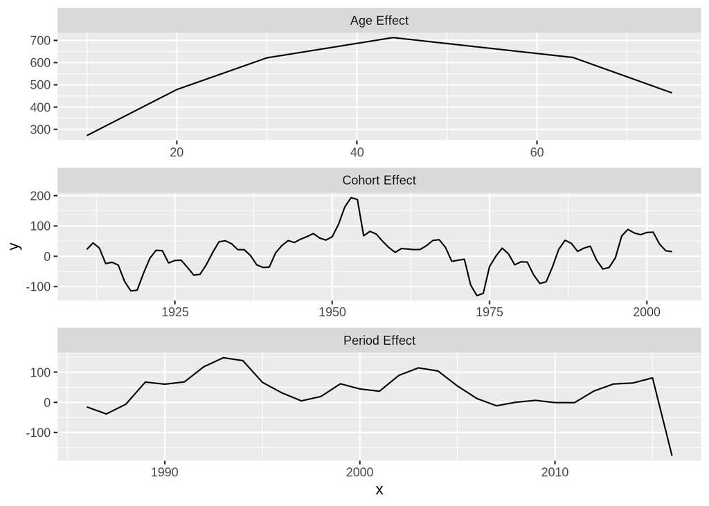

```r
ggplot(apc_all, aes(x, y)) +
  geom_line() +
  facet_wrap(~ group, scales = "free", ncol = 1)
```

From plot above we can identify Age, Period and Cohort effect of suicides. But it’s not capturing all of our the data dynamics, lets try it to more specific cases from the data. We filltered the data by sex and country:

```r
suicides_male_us <- suicides %>%
  filter(
    sex == "male",
    country == "United States"
  )

suicides_male_us
```

| suicides | age | age_squared | period | cohort | sex | country |
| --- | --- | --- | --- | --- | --- | --- |
| 2177 | 75 | 5625 | 1985 | 1910 | male | United States |
| 5302 | 64 | 4096 | 1985 | 1921 | male | United States |
| 5134 | 30 | 900 | 1985 | 1955 | male | United States |
| 6053 | 44 | 1936 | 1985 | 1941 | male | United States |
| 4267 | 20 | 400 | 1985 | 1965 | male | United States |
| 205 | 10 | 100 | 1985 | 1975 | male | United States |
| 2340 | 75 | 5625 | 1986 | 1911 | male | United States |
| 5500 | 64 | 4096 | 1986 | 1922 | male | United States |
| 5450 | 30 | 900 | 1986 | 1956 | male | United States |
| 6450 | 44 | 1936 | 1986 | 1942 | male | United States |

[output cut: 176 more lines]

Now we have our data that contained APC variables of `male` in `United States`. For the next step we applied linear regression to extract coefficient of APC from the data :

```r
apc_lm <- lm(suicides ~ age + age_squared + period + cohort, suicides_male_us)

summary(apc_lm)
```

```
##
## Call:
## lm(formula = suicides ~ age + age_squared + period + cohort,
##     data = suicides_male_us)
##
## Residuals:
##     Min      1Q  Median      3Q     Max
## -2474.8  -378.9     0.0   439.4  2474.8
##
## Coefficients: (1 not defined because of singularities)
##               Estimate Std. Error t value          Pr(>|t|)
## (Intercept) -5925.2423  1716.8546  -3.451           0.00104 **
## age           433.4174    47.4850   9.127 0.000000000000701 ***
## age_squared    -4.3385     0.4684  -9.262 0.000000000000419 ***
## period1986   -234.8724  1515.8754  -0.155           0.87740
## period1987   -377.2245  1590.8747  -0.237           0.81339
## period1988   -114.9018  1562.8255  -0.074           0.94164
## period1989    332.2516  1468.4095   0.226           0.82178
## period1990    399.7556  1534.8937   0.260           0.79543
## period1991    329.7095  1471.5206   0.224           0.82348
## period1992    912.2598  1591.6599   0.573           0.56872
## period1993   1023.7514  1593.4089   0.642           0.52304
## period1994    787.2440  1522.2825   0.517           0.60699
## period1995    478.5536  1170.8616   0.409           0.68423
## period1996   -471.4333  1372.8457  -0.343           0.73252
## period1997   -606.9015  1555.5320  -0.390           0.69783
## period1998   -413.7255  1535.9278  -0.269           0.78859
## period1999    220.0764  1299.5798   0.169           0.86611
## period2000    238.8850  1451.0640   0.165           0.86980
## period2001    435.6227  1441.6270   0.302           0.76358
## period2002   1223.3076  1531.3070   0.799           0.42757
## period2003   1498.8270  1533.8367   0.977           0.33247
## period2004   1457.0321  1471.2956   0.990           0.32607
## period2005    827.0042  1150.5815   0.719           0.47512
## period2006    331.3115  1484.2611   0.223           0.82414
## period2007    260.8998  1593.2016   0.164           0.87048
## period2008    565.8727  1603.4460   0.353           0.72541
## period2009   1053.6846  1402.4886   0.751           0.45546
## period2010   1262.4640  1529.5100   0.825           0.41247
## period2011   1440.0666  1551.2895   0.928           0.35703
```

[output cut: 90 more lines]

```
## cohort1997   1895.0188  2670.1223   0.710           0.48068
## cohort1998   1613.0459  2679.0297   0.602           0.54941
## cohort1999   1146.2341  2629.8720   0.436           0.66453
## cohort2000    949.4546  2667.0024   0.356           0.72311
## cohort2001    785.8521  2640.8477   0.298           0.76707
## cohort2002    267.1235  2710.4500   0.099           0.92183
## cohort2003    -46.0542  2732.6571  -0.017           0.98661
## cohort2004   -144.8584  2692.9176  -0.054           0.95728
## cohort2005          NA         NA      NA                NA
## ---
## Signif. codes:  0 '***' 0.001 '**' 0.01 '*' 0.05 '.' 0.1 ' ' 1
##
## Residual standard error: 1577 on 59 degrees of freedom
## Multiple R-squared:  0.9105, Adjusted R-squared:  0.7194
## F-statistic: 4.765 on 126 and 59 DF,  p-value: 0.0000000003789
```

Again, from tidied coefficients, we need to tidy our results:

```r
apc_tidy <- tidy(apc_lm)

pc_tidy <- apc_tidy %>%
  mutate(
    key = str_replace_all(term, "[:digit:]", ""),
    value = str_replace_all(term, "[:alpha:]", "") %>% as.numeric()
  ) %>% # seperate digit number and alphabet of term
  select(key, value, estimate) %>%
  filter(key == "period" | key == "cohort") %>%
  spread(key, value)
age_coef <- apc_tidy %>%
  filter(term == "age") %>%
  pull(estimate)

age_squared_coef <- apc_tidy %>%
  filter(term == "age_squared") %>%
  pull(estimate)

period_coef <- pc_tidy %>%
  select(x = period, y = estimate) %>%
  drop_na()

cohort_coef <- pc_tidy %>%
  select(x = cohort, y = estimate) %>%
  drop_na()
```

Now we can calculate the age effect, then combine all the coefficient together:

```r
apc_all_male_us <- suicides_male_us %>%
  mutate(age_effect = (age * age_coef) + (age_squared * age_squared_coef)) %>%
  select(x = age, y = age_effect) %>%
  distinct() %>%
  mutate(group = "Age Effect") %>%
  bind_rows(mutate(period_coef, group = "Period Effect")) %>%
  bind_rows(mutate(cohort_coef, group = "Cohort Effect")) %>%
  select(group, x, y) %>%
  arrange(x)

apc_all_male_us
```

| group | x | y |
| --- | --- | --- |
| Age Effect | 10 | 3900.32367 |
| Age Effect | 20 | 6932.94743 |
| Age Effect | 30 | 9097.87129 |
| Age Effect | 44 | 10671.02885 |
| Age Effect | 64 | 9968.21710 |
| Age Effect | 75 | 8102.24230 |
| Cohort Effect | 1911 | 397.87239 |
| Cohort Effect | 1912 | 732.22448 |
| Cohort Effect | 1913 | 485.90176 |
| Cohort Effect | 1914 | -47.25156 |

[output cut: 120 more lines]

The last we visualize the estimated coefficient to get some insight regarding our APC decomposition:

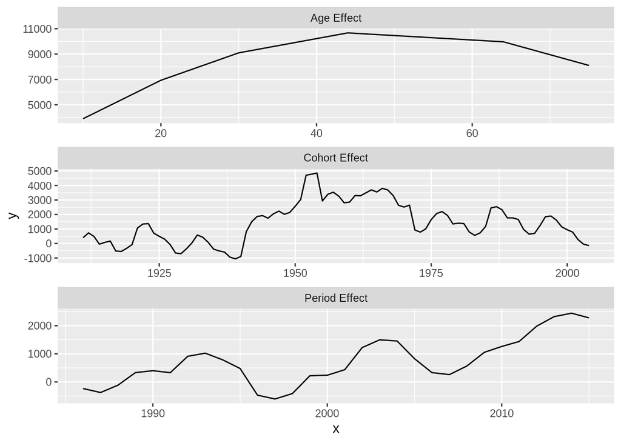

```r
ggplot(apc_all_male_us, aes(x, y)) +
  geom_line() +
  facet_wrap(~ group, scales = "free", ncol = 1)
```

*dive deeper*

Create APC analysis, try to compare the APC of `female` in `United States` with the APC we get above:

```r
suicides_female_us <- suicides %>%
  filter(
    sex == "female",
    country == "United States"
  )

suicides_female_us
```

# 3 Annotations

[^1]: Yang Y, Schulhofer‐Wohl S, Fu WJ, Land KC. The Intrinsic Estimator for Age‐Period‐Cohort Analysis: What It Is and How to Use It1. American Journal of Sociology 2008;113(6):1697-736.
[^2]: Mason, Karen Oppenheim, et al. “Some methodological issues in cohort analysis of archival data.” American sociological review (1973): 242-258
[^3]: Keyes KM, Utz RL, Robinson W, Li G. What is a cohort effect? Comparison of three statistical methods for modeling cohort effects in obesity prevalence in the United States, 1971-2006. Soc Sci Med 2010;70(7):1100-8